# Working with discreteRV

Eric Hare

2015-09-15

discreteRV is an R package that allows simple creation and manipluation of discrete random variables using a clean and familiar syntactical interface. This vignette will guide you through the basic operations supported by discreteRV.

## Creating discrete random variables

```r
(X <- RV(outcomes = 1:6, probs = 1/6))
```

```
## Random variable with 6 outcomes
##
## Outcomes   1   2   3   4   5   6
## Probs    1/6 1/6 1/6 1/6 1/6 1/6
```

Probabilities are uniform by default, so the following code is equivalent:

```r
(X <- RV(1:6))
```

```
## Random variable with 6 outcomes
##
## Outcomes   1   2   3   4   5   6
## Probs    1/6 1/6 1/6 1/6 1/6 1/6
```

Outcomes can be specified as a range of values, which is useful for distributions in which the outcomes that can occur with non-zero probability are unbounded. To define a Poisson random variable Y, we specify the outcomes as a range and the probabilities as a function:

```r
pois.func <- function(y, lambda) { return(lambda^y * exp(-lambda) / factorial(y)) }

(Y <- RV(outcomes = c(0, Inf), probs = pois.func, lambda = 2))
```

```
## Random variable with outcomes from 0 to Inf
##
## Outcomes     0     1     2     3     4     5     6     7     8     9    10    11
## Probs    0.135 0.271 0.271 0.180 0.090 0.036 0.012 0.003 0.001 0.000 0.000 0.000
##
## Displaying first 12 outcomes
```

Several common distributions are natively supported so that the function need not be defined manually. For instance, an equivalent method of defining Y is:

```r
(Y <- RV("poisson", lambda = 2))
```

```
## Random variable with outcomes from 0 to Inf
##
## Outcomes     0     1     2     3     4     5     6     7     8     9    10    11
## Probs    0.135 0.271 0.271 0.180 0.090 0.036 0.012 0.003 0.001 0.000 0.000 0.000
##
## Displaying first 12 outcomes
```

The RV function also allows the definition of a random variable in terms of odds. We construct a loaded die in which a roll of one is four times as likely as any other roll as:

```r
(X.loaded <- RV(outcomes = 1:6, odds = c(4, 1, 1, 1, 1, 1)))
```

```
## Random variable with 6 outcomes
##
## Outcomes   1   2   3   4   5   6
## Odds     4:5 1:8 1:8 1:8 1:8 1:8
```

## Probability Calculations

Basic probability calculations are performed using the $P$ function, such as:

```r
P(X == 2)
```

```
## [1] 0.1666667
```

```r
P(X < 3)
```

```
## [1] 0.3333333
```

```r
P(X < 3 | X < 4)
```

```
## [1] 0.6666667
```

Consider our Poisson random variable Y, and suppose we want to obtain the probability that Y is within a distance $\delta$ of its mean parameter $\lambda = 2$:

```r
delta <- 3
lambda <- 2

P((Y >= lambda - delta) %AND% (Y <= lambda + delta))
```

```
## [1] 0.9834364
```

Alternatively, we could have also used the slightly more complicated looking expression:

```r
P((Y - lambda)^2 <= delta^2)
```

```
## [1] 0.9834364
```

We can compute several other distributional quantities, including the expected value and the variance of a random variable:

```r
E(X)
```

```
## [1] 3.5
```

```r
V(X)
```

```
## [1] 2.916667
```

```r
E( (X-E(X))^2 )
```

```
## [1] 2.916667
```

## Joint Distributions

A joint distribution can be defined with the jointRV function, with a list of possible outcomes and probabilities in row-major order:

```r
(AandB <- jointRV(outcomes = list(1:3, 0:2), probs = 1:9 / sum(1:9)))
```

```
## Random variable with 9 outcomes
##
## Outcomes  1,0  1,1  1,2  2,0  2,1  2,2  3,0  3,1  3,2
## Probs    1/45 2/45 1/15 4/45  1/9 2/15 7/45 8/45  1/5
```

The individual marginal distributions can be obtained by use of the marginal function:

```r
A <- marginal(AandB, 1)
B <- marginal(AandB, 2)
```

Although the marginal distributions allow all the same computations of any univariate random variable, they maintain a special property. The joint distribution that produced the marginals is stored as attributes in the object. This allows for several more advanced probability calculations, involving the marginal and conditional distributions:

```r
P(A < B)
```

```
## [1] 0.06666667
```

```r
P(A == 2 | B > 0)
```

```
## [1] 0.3333333
```

```r
P(A == 2 | (B == 1) %OR% (B == 2))
```

```
## [1] 0.3333333
```

```r
independent(A, B)
```

```
## [1] FALSE
```

```r
A | (A > 1)
```

```
## Random variable with 2 outcomes
##
## Outcomes    2    3
## Probs    5/13 8/13
```

```r
A | (B == 2)
```

```
## Random variable with 3 outcomes
##
## Outcomes   1   2   3
## Probs    1/6 1/3 1/2
```

```r
E(A | (B == 2))
```

```
## [1] 2.333333
```

A joint distribution can be defined from a univariate distribution using the iid function (to create a joint distribution of n independent realizations of the specified random variable) of the SofIID function (to create a distribution for the sum of n independent realizations of the random variable):

```r
(X2 <- iid(X, n = 2))
```

```
## Random variable with 36 outcomes
##
## Outcomes  1,1  1,2  1,3  1,4  1,5  1,6  2,1  2,2  2,3  2,4  2,5  2,6
## Probs    1/36 1/36 1/36 1/36 1/36 1/36 1/36 1/36 1/36 1/36 1/36 1/36
##
## Displaying first 12 outcomes
```

```r
(X3 <- iid(X, n = 3))
```

```
## Random variable with 216 outcomes
##
## Outcomes 1,1,1 1,1,2 1,1,3 1,1,4 1,1,5 1,1,6 1,2,1 1,2,2 1,2,3 1,2,4 1,2,5 1,2,6
## Probs    1/216 1/216 1/216 1/216 1/216 1/216 1/216 1/216 1/216 1/216 1/216 1/216
##
## Displaying first 12 outcomes
```

```r
(X2 <- SofIID(X, n = 2))
```

```
## Random variable with 11 outcomes
##
## Outcomes    2    3    4    5    6    7    8    9   10   11   12
## Probs    1/36 1/18 1/12  1/9 5/36  1/6 5/36  1/9 1/12 1/18 1/36
```

```r
(X20 <- SofIID(X, n = 20, progress = FALSE))
```

```
## Random variable with 77 outcomes
##
## Outcomes 32 33 34 35 36 37 38 39 40 41 42 43
## Probs     0  0  0  0  0  0  0  0  0  0  0  0
##
## Displaying first 12 outcomes
```

Alternatively, the `+` and `*` operators have been overloaded to allow these computations in a cleaner syntax, such as:

```r
RV(1:6) + RV(1:6)
```

```
## Random variable with 11 outcomes
##
## Outcomes    2    3    4    5    6    7    8    9   10   11   12
## Probs    1/36 1/18 1/12  1/9 5/36  1/6 5/36  1/9 1/12 1/18 1/36
```

## Plotting

Plot and qqnorm methods are defined for random variable objects:

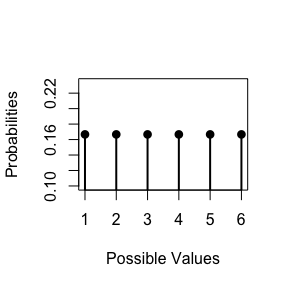

```r
plot(X)
```

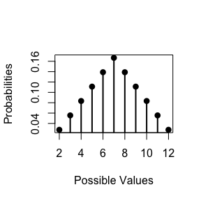

```r
plot(X2)
```

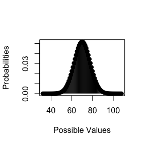

```r
plot(X20)
```

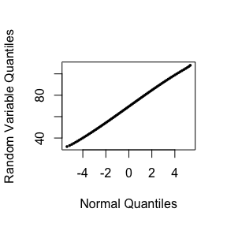

```r
qqnorm(X20)
abline()
```

## Simulation

discreteRV also includes a set of functions to simulate trials from a random variable.

```r
(X.sim <- rsim(X, 10))
```

```
## Simulated Vector:  3 3 5 6 3 4 1 2 3 6
##
## Random variable with 6 outcomes
##
## Outcomes   1   2   3   4   5   6
## Probs    1/6 1/6 1/6 1/6 1/6 1/6
```

```r
props(X.sim)
```

```
## RV
##   1   2   3   4   5   6
## 0.1 0.1 0.4 0.1 0.1 0.2
```

```r
Prop(X.sim == 3)
```

```
## [1] 0.4
```

```r
Prop(X.sim > 3)
```

```
## [1] 0.4
```

Craps is a common dice game played in casinos. The game begins with what is called the “Come Out” roll, in which two fair dice are rolled. If a sum of seven or eleven is obtained, the player wins. If a sum of two, three, or twelve is obtained, the player loses. In all other cases, the roll obtained is declared the ``Point" and the player rolls again in an attempt to obtain this same point value. If the player rolls the Point, they win, but if they roll a seven, they lose. Rolls continue until one of these two outcomes is achieved.

```r
(Roll <- RV(1:6) + RV(1:6))
```

```
## Random variable with 11 outcomes
##
## Outcomes    2    3    4    5    6    7    8    9   10   11   12
## Probs    1/36 1/18 1/12  1/9 5/36  1/6 5/36  1/9 1/12 1/18 1/36
```

Recall that the game ends after the first roll if and only if a seven or eleven is obtained (resulting in a win), or a two, three, or twelve is obtained (resulting in a loss). Hence, we calculate the probability that the game ends after the first roll as follows:

```r
P(Roll %in% c(7, 11, 2, 3, 12))
```

```
## [1] 0.3333333
```

Now suppose we would like to condition on the game having ended after the first roll. Using the conditional probability operator in discreteRV, we can obtain the probabilities of winning and losing given that the game ended after the first roll:

```r
P(Roll %in% c(7, 11) | Roll %in% c(7, 11, 2, 3, 12))
```

```
## [1] 0.6666667
```

```r
P(Roll %in% c(2, 3, 12) | Roll %in% c(7, 11, 2, 3, 12))
```

```
## [1] 0.3333333
```

```r
TwoRolls <- iid(Roll, 2)

First <- marginal(TwoRolls, 1)
Second <- marginal(TwoRolls, 2)

P(First %in% c(7, 11) %OR% (First %in% 4:10 %AND% (First == Second)))
```

```
## [1] 0.2993827
```

```r
craps_game <- function(RV) {

    my.roll <- rsim(RV, 1)

    if (my.roll %in% c(7, 11)) { return(1) }
    else if (my.roll %in% c(2, 3, 12)) { return(0) }
    else {
        new.roll <- 0
        while (new.roll != my.roll & new.roll != 7) {
            new.roll <- rsim(RV, 1)
        }

        return(as.numeric(new.roll == my.roll))
    }
}

sim.results <- replicate(100000, craps_game(Roll))
mean(sim.results)
```

```
## [1] 0.49325
```